# KeyGenes

Davy Cats

Sequencing Analysis Support Core, Department of Biomedical Data Sciences, Leiden University Medical Center, Leiden, The Netherlands  
d.cats@lumc.nl

2019-04-30

# What is KeyGenes

KeyGenes is an algorithm to predict the identity and determines identity scores of queried samples (test set) based on a provided group of samples (training set). It uses transcriptional profiles of the test set and matches them to the transcriptional profiles of the training set. KeyGenes uses 10-fold cross validation on the basis of LASSO (Least Absolute Shrinkage and Selection Operator) regression available in the `glmnet` R-package (Friedman et al., 2010).

# This vignette

This vignette will describe the usage of the `KeyGenes` R-package. First, the included dataset (usable as trainingdata) will be described. Secondly, the usage of the base KeyGenes algorithmm, the results and visualization of these results will be explained. Finally a full workflow for sample classification using KeyGenes will be given. This workflow can be used to automatically select the approriate training data for each test sample.

# Included training data

Included in the KeyGenes package is a collection of RNA-seq count data usable for training. These data have been collected in a [*SummarizedExperiment*](http://bioconductor.org/packages/SummarizedExperiment/) object.

```r
library(KeyGenes)
data("training.data")
training.data
```

```
## class: SummarizedExperiment
## dim: 63436 176
## metadata(0):
## assays(1): counts
## rownames(63436): ENSG00000000003 ENSG00000000005 ...
##   ENSG00000269882 ENSG00000269884
## rowData names(2): hgnc_id symbol
## colnames(176): hESC stem cells.DH3 hESC stem cells.DH6 ...
##   muscle_adult gonad_adult.10
## colData names(2): age organ
```

This dataset contains hESC samples (Forster et al., 2014; Roost et al., 2015), 1st and 2nd trimester fetal samples (Roost et al., 2015) and adult samples (Cnop et al., 2014; Fagerberg et al., 2014; Illumina Body Map 2.0). Each sample is annotated in the `colData` with their `age` and `organ` of origin.

```r
table(training.data$age)
```

```
##
##   1st trimester   2nd trimester           Adult hESC stem cells
##              36              75              61               4
```

```r
table(training.data$organ)
```

```
##
##         adrenal          amnion           brain         chorion
##               6               7               9               3
##             eye           gonad           heart         heart A
##               6              15               5               4
##         heart V hESC stem cells       intestine          kidney
##               5               4              18              11
##           liver            lung          mother          muscle
##              10              12               3               7
##        pancreas        placenta            skin     spinal cord
##               9               7               8               2
##          spleen         stomach          tongue  umbilical cord
##               8               9               6               2
```

One can use these annotations to select the samples approriate for their use case.

```r
my.training.set <- training.data[, training.data$age == "2nd trimester"]
table(my.training.set$age)
```

```
##
## 2nd trimester
##            75
```

Counts may not be available for all genes for all samples. The `complete.cases` function can be used to remove genes with missing values.

```r
library(SummarizedExperiment)
my.training.set <- my.training.set[complete.cases(assay(my.training.set)),]
my.training.set
```

```
## class: SummarizedExperiment
## dim: 28978 75
## metadata(0):
## assays(1): counts
## rownames(28978): ENSG00000000003 ENSG00000000005 ...
##   ENSG00000235727 ENSG00000235729
## rowData names(2): hgnc_id symbol
## colnames(75): pancreas_16-18 skin_16-18 ... lung_22.1 stomach_22.1
## colData names(2): age organ
```

# Running KeyGenes

The `keygenes.NGS` function canbe used to run the KeyGenes algorithm. The input for this function is a `matrix` or `SummarizedExperiment` object for both the test and training data, as well as a (character) vector either giving the class (eg. organ) for each sample in the training data or the name of the column in the `SummarizedExperiment`’s `colData` containing these classes.

```r
# Make a subset of samples for testing
set.seed(111)
test.samples <- sample(1:ncol(my.training.set), 4)

# Run KeyGenes
result <- keygenes.NGS(my.training.set[, test.samples],
                       my.training.set[, -test.samples],
                       "organ")
```

## The results

The returned object contains a number of slots. The most important ones are the following: `result`, `class.genes` and `prediction.matrix`.

### The result slot

The `result` slot contains the final classifications of the test samples:

```r
result@result
```

```
##                truth predicted
## muscle_22         NA    muscle
## intestine_22.1    NA intestine
## stomach_16-18     NA   stomach
## pancreas_22       NA  pancreas
```

If we had provided the `test.classes` parameter to the `keygenes.NGS` function, the `truth` column would have contained these values and the `accuracy` slot would have contained the a percentage of correct predictions.

### The class.genes slot

The `class.genes` slot contains the key genes in the classification. For each class, the genes which had an effect on the prediction (a coeficient larger than 0) is returned.

```r
result@class.genes
```

```
## $adrenal
## [1] "ENSG00000105298" "ENSG00000112033" "ENSG00000146067"
##
## $amnion
## [1] "ENSG00000093217" "ENSG00000112851" "ENSG00000128045" "ENSG00000166896"
## [5] "ENSG00000175040" "ENSG00000177993" "ENSG00000182667"
##
## $brain
##  [1] "ENSG00000104313" "ENSG00000128045" "ENSG00000128274"
##  [4] "ENSG00000131389" "ENSG00000147416" "ENSG00000159263"
##  [7] "ENSG00000163806" "ENSG00000168787" "ENSG00000170469"
## [10] "ENSG00000186094" "ENSG00000224263"
##
## $chorion
## [1] "ENSG00000002726" "ENSG00000069849" "ENSG00000079557" "ENSG00000105376"
## [5] "ENSG00000106178" "ENSG00000143217" "ENSG00000165185" "ENSG00000183566"
## [9] "ENSG00000197706"
##
## $eye
## [1] "ENSG00000080007" "ENSG00000086475" "ENSG00000146457" "ENSG00000177596"
## [5] "ENSG00000181577" "ENSG00000182963"
##
## $gonad
## [1] "ENSG00000101017" "ENSG00000115421" "ENSG00000135973" "ENSG00000151338"
## [5] "ENSG00000159377" "ENSG00000165953"
##
## $`heart A`
## [1] "ENSG00000089177" "ENSG00000147509" "ENSG00000227069"
##
## $`heart V`
## [1] "ENSG00000111011" "ENSG00000135355" "ENSG00000159263" "ENSG00000187969"
## [5] "ENSG00000226781"
##
## $intestine
## [1] "ENSG00000017260" "ENSG00000160588" "ENSG00000171867" "ENSG00000229762"
##
## $kidney
## [1] "ENSG00000074800" "ENSG00000116031" "ENSG00000165655"
##
## $liver
```

[output cut: 19 more lines]

```
## [5] "ENSG00000227258"
##
## $skin
## [1] "ENSG00000106799" "ENSG00000138759" "ENSG00000166788" "ENSG00000184992"
## [5] "ENSG00000185442"
##
## $spleen
## [1] "ENSG00000073754" "ENSG00000132635" "ENSG00000136327" "ENSG00000179796"
## [5] "ENSG00000197013" "ENSG00000198804"
##
## $stomach
## [1] "ENSG00000134243" "ENSG00000158485" "ENSG00000158486" "ENSG00000205029"
##
## $tongue
## [1] "ENSG00000132510" "ENSG00000162433" "ENSG00000168264"
```

#### Getting gene symbols instead of ensembl ids

The genes in the class.genes slot will be named in accordance with the names the were assigned in the count tables provided as input. For the provided training data these are ensembl ids. In the `rowData` for the `training.data` object additional gene names are provided (HGNC IDs and gene symbols). Note that these alternatives may not be available for all genes.

If you want to see the `class.genes` as symbols, rather than ensembl ids, the following code can be used.

```r
class.genes.symbols <- lapply(result@class.genes, function(x){
    rowData(training.data[x,])[,"symbol"]
})
class.genes.symbols
```

```
## $adrenal
## [1] "CACTIN"  "PPARD"   "FAM193B"
##
## $amnion
## [1] "XYLB"      "ERBIN"     "RASL11B"   "ATP23"     "CHST2"     "ZNRF3-AS1"
## [7] "NTM"
##
## $brain
##  [1] "EYA1"     "RASL11B"  "A4GALT"   "SLC6A6"   "ATP6V1B2" "SIM2"
##  [7] "SPDYA"    NA         "SPATA24"  "AGBL4"    "CYCSP12"
##
## $chorion
## [1] "AOC1"     "ATP1B3"   "AFM"      "ICAM5"    "CCL24"    "NECTIN4"
## [7] "KIAA1958" "BPIFA4P"  "OR6C74"
##
## $eye
## [1] "DDX43"    "SEPHS1"   "WTAP"     NA         "C6orf223" "GJC1"
##
## $gonad
## [1] "CD40"      "PAPOLG"    "GPR45"     "MIPOL1"    "PSMB4"     "SERPINA12"
##
## $`heart A`
## [1] "KIF16B" "RGS20"  "CNN2P2"
##
## $`heart V`
## [1] "RSRC2"   "GJA10"   "SIM2"    "ZCCHC13" "TBCAP1"
##
## $intestine
## [1] "ATP2C1" "MPZL3"  "PRNP"   NA
##
## $kidney
## [1] "ENO1"   "CD207"  "ZNF503"
##
## $liver
## [1] "GSDMD"   "LMAN2L"  "NECTIN4" "DCDC1"   "FOXD4L1" "IRF7"
##
## $lung
## [1] "PPM1K" "KLK1"
##
## $mother
## [1] "AAK1"    "YIPF2"   "FBXO4"   "HOXB9"   "C8orf33" "MSANTD1"
##
## $muscle
## [1] "AAMDC"  "BARHL2" "AK4"    "IRF2"   "FZD2"   "GJC1"   NA
##
## $pancreas
## [1] "SMC4"   "RNF157" "PIGM"   "DEFA7P"
##
## $placenta
## [1] "CD5L"      "PPP1R3C"   "OTOP1"     "XPO6"      "SMIM2-AS1"
##
## $skin
## [1] "TGFBR1"  "FRAS1"   "SAAL1"   "BRI3BP"  "FAM174B"
##
## $spleen
## [1] "CD5L"   "PCED1A" "NKX2-8" "LRRC3B" "ZNF429" "MT-CO1"
##
## $stomach
## [1] "SORT1"  "CD1B"   "DNAH3"  "OR5D16"
##
## $tongue
## [1] "KDM6B"   "AK4"     "IRF2BP2"
```

### The prediction.matrix slot

The `prediction.matrix` slot contains linear predictor values. The final predictions are chosen by picking the class with the highest value for each sample.

```r
result@prediction.matrix
```

```
##              muscle_22 intestine_22.1 stomach_16-18  pancreas_22
## adrenal   0.0030482516   6.938455e-04  2.734436e-04 0.0001096321
## amnion    0.0004918695   6.056142e-05  1.267502e-04 0.0005240460
## brain     0.0008408268   7.948537e-04  2.199399e-03 0.0046494785
## chorion   0.0001980717   3.001224e-05  8.444381e-05 0.0015856262
## eye       0.0016380161   3.283603e-05  9.814531e-04 0.0005749678
## gonad     0.0018096818   2.799284e-04  8.080725e-04 0.0007133202
## heart A   0.0004796314   2.166242e-04  1.171348e-03 0.0001408455
## heart V   0.0046946609   6.698917e-05  4.377744e-05 0.0001476011
## intestine 0.0003977874   9.955755e-01  2.078633e-02 0.0003250604
## kidney    0.0003899224   3.402144e-05  3.241324e-04 0.0002840320
## liver     0.0001604832   3.521787e-04  2.782975e-04 0.0009157060
## lung      0.0011152981   3.899581e-05  6.570957e-03 0.0004231700
## mother    0.0081841593   3.929244e-04  5.845890e-04 0.0016040991
## muscle    0.9597838614   1.481000e-04  2.318691e-04 0.0006464012
## pancreas  0.0019271654   3.287257e-04  1.786403e-04 0.9729857642
## placenta  0.0004823425   3.020367e-05  7.321994e-05 0.0002511530
## skin      0.0002708697   9.984445e-05  1.016793e-04 0.0007573200
## spleen    0.0068305872   1.013678e-04  2.313699e-04 0.0126593590
## stomach   0.0005990487   5.441142e-04  9.644811e-01 0.0003159813
## tongue    0.0066574647   1.783637e-04  4.691018e-04 0.0003864363
```

## Plotting the predictions

The predictions can be visualized using the `keygenes.heatmap` function. This will draw a heatmap based on the `prediction.matrix`.

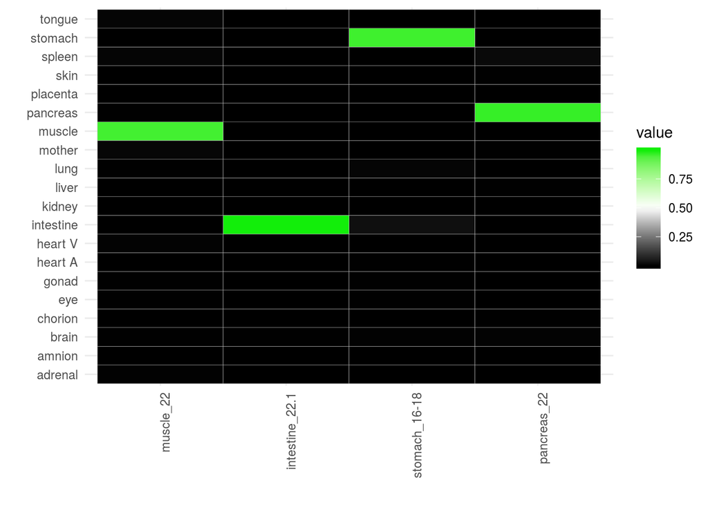

```r
keygenes.heatmap(result)
```

# Selecting training data automatically

In many cases it will be hard to tell exactly what data from the training set is most approriate for our test data. For example, when differentiating stem cell it is unknow whether the resulting cells are more akin to fetal or adult cells and this might differ between samples, depending on the timepoints which are measured.

## Predicting age

In order to select the appropriate training data for each sample, the age of each sample is predicted first.

```r
# Create a test and training set
set.seed(111)
training.data <- training.data[complete.cases(assay(training.data)),]
test.samples <- sample(1:ncol(training.data), 4)
test.set <- training.data[,test.samples]
training.set <- training.data[,-test.samples]

# Run KeyGenes
age.result <- keygenes.NGS(test.set, training.set, "age")
age.result@result
```

```
##                   truth     predicted
## amnion_22.1          NA 2nd trimester
## intestine_adult.6    NA         Adult
## skin_22              NA 2nd trimester
## eye_16-18.1          NA 2nd trimester
```

## Predicting organ

Now that the ages of the samples are known, an appropriate set of test data can be selected for predicting the organs.

```r
# Get the possible ages
ages <- as.character(unique(age.result@result$predicted))

# Run KeyGenes for each age category
organ.results <- sapply(ages, function(age) {
    # Further predictions for hESC stem cells are not possible!
    if (age != "hESC stem cells") {
        # Select the samples for each age.
        train.subset <- training.set[, training.set$age == age]
        test.subset <- test.set[, age.result@result$predicted == age]
        # Test sets need at least two samples
        if (ncol(test.subset) < 2) {
            test.subset <- cbind(test.subset, test.subset)
            colnames(test.subset) <- c(colnames(test.subset)[1], "duplicate")
        }
        # Run KeyGenes for each subset.
        #return(keygenes.NGS(test.subset, train.subset, "organ"))
        r <- keygenes.NGS(test.subset, train.subset, "organ")
    }
})
names(organ.results) <- ages
organ.results[sapply(organ.results, is.null)] <- NULL

# Merge the predictions
all.organs <- organ.results[[1]]@result
if (length(organ.results) > 1) {
    for (x in 2:length(organ.results)) {
        all.organs <- rbind(all.organs, organ.results[[x]]@result)
    }
}
all.organs <- all.organs[rownames(all.organs) != c("duplicate"),]
all.organs
```

```
##                   truth predicted
## amnion_22.1          NA    amnion
## skin_22              NA      skin
## eye_16-18.1          NA       eye
## intestine_adult.6    NA intestine
```

## Making a heatmap

The following code can be used to generate a heatmap for these results. This heatmap will show both the age prediction values and the organ prediction values.

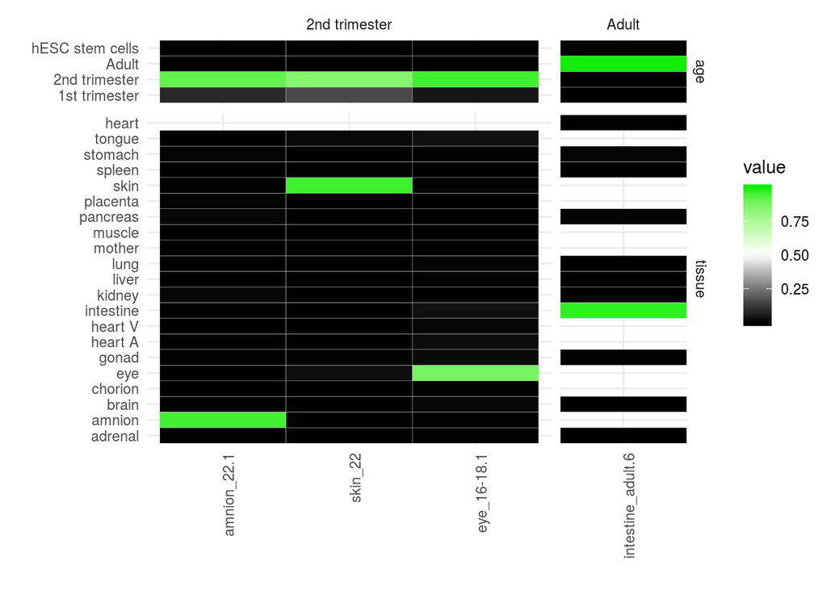

```r
library(ggplot2)

#
melted.prediction.matrix.list <- lapply(names(organ.results), function(age) {
    # Melt the prediction matrix
    melted <- melt(organ.results[[age]]@prediction.matrix)
    # Annotate each value with the age
    melted["age"] <- age
    # Label it as a tissue prediction value
    melted["type"] <- "tissue"
    melted <- melted[melted$Var2 != "duplicate",]
})

# Merge all the ages into one table
melted.prediction.matrix <- melted.prediction.matrix.list[[1]]
if (length(organ.results) > 1) {
    for (x in 2:length(organ.results)){
        melted.prediction.matrix <- rbind(melted.prediction.matrix,
                                          melted.prediction.matrix.list[[x]])
    }
}

# Melt the age prediction matrix and add it as well.
melted.ages <- melt(age.result@prediction.matrix)
melted.ages["age"] <- age.result@result[melted.ages$Var2, "predicted"]
melted.ages["type"] <- "age"
melted.prediction.matrix <- rbind(melted.prediction.matrix, melted.ages)

# Plot it
g <- ggplot(data=melted.prediction.matrix)
g <- g + theme_minimal()
g <- g + geom_tile(aes(fill=value, x=Var2, y=Var1), color="gray")
g <- g + scale_fill_gradient2(low="black", mid="white", high = "green2",
                              midpoint = 0.5)
g <- g + labs(x="", y="")
g <- g + facet_grid(type~age, space = "free", scales = "free")
g <- g + theme(axis.text.x = element_text(angle = 90, hjust = 1),
               axis.ticks = element_blank())
g
```

# References

Cnop, M., Abdulkarim, B., Bottu, G., Cunha, D.A., Igoillo-Esteve, M., Masini, M., Turatsinze, J.V., Griebel, T., Villate, O., Santin, I., et al. (2014). RNA sequencing identifies dysregulation of the human pancreatic islet transcriptome by the saturated fatty acid palmitate. *Diabetes*. 63(6): 1978-1993.

Fagerberg, L., Hallstrom, B.M., Oksvold, P., Kampf, C., Djureinovic, D., Odeberg, J., Habuka, M., Tahmasebpoor, S., Danielsson, A., Edlund, K., et al. (2014). Analysis of the human tissue-specific expression by genome-wide integration of transcriptomics and antibody-based proteomics. *Molecular & cellular proteomics: MCP*. 13(2): 397-406.

Forster R., Chiba K., Shaeffer L., Regalado S.G., Lai C.S., Gao Q., Kiani S., Farin H.F., Clevers H., Cost G.J., et al. (2014) Human intestinal tissue with adult stem cell properties derived from pluripotent stem cells. *Stem cell reports*. 2(6): 838-852.

Friedman J., Hastie T., and Tibshirani R. (2010). Regularization paths for generalized linear models via coordinate descent. *Journal of statistical software*. 33(1): 1-22.

Roost M.S., van Iperen L., Ariyurek Y., Buermans H.P., Arindrarto W., Devalla H.D., Passier R., Mummery C.L., Carlotti F., de Koning E.J.P., van Zwet E.W., Goeman J.J., and Chuva de Sousa Lopes S.M. (2015). KeyGenes, a tool to probe tissue differentiation using a human fetal transcriptional atlas. *Stem Cell Reports*. 4(6):1112-24.